# 資料案例：老忠實

第 14 組

2019-04-01 14:07:50

🗿 問題討論：

#### 【A.選擇方法】

■ 我們為甚麼需要隨機變數？什麼時候我們需要用到隨機變數？

```
Ans:因為我們沒辦法得到母體完整的資料，所以我們需要抽樣，而隨機變數則是抽樣後我們所做的多次隨機實驗的結果。
```

■ 隨機變數沒有固定的值，那我們要如何做計算呢？

```
Ans:設置數值區間，讓我們可以在區間範圍內推估數值。
```

■ 我們可以用直方圖或數值標記來估計噴發時間落在某一區間的機率嗎？

```
Ans:可以。
```

■ 直方圖(histogram)也可以當作一種模型嗎？數值標記(rug)呢？

```
Ans:都可以。
```

■ 直方圖和平滑模型哪一個比較適合用來表示噴發時間的分布？為甚麼？

```
Ans:直方圖，因為我們可以根據需求來調整頻寬，得知在時間內的時間分布。
```

■ 用數值標記來預測噴發時間會比用直方圖「準」嗎？「準」是什麼意思呢？

```
Ans:
1.不一定，當用來預測原樣本資料時，準確度很高，但用來預測原樣本以外的資料時，準確度會降低。
2.「準」是指預測與真實的誤差很小。
```

#### 【B.調整參數】調整一下模型參數的滑桿 …

■ 你覺得最合適的直方圖欄數(`support/binwidth`)是？為甚麼？

```
Ans:16，看起來較平滑，不會過於複雜，但也有足夠的準確度。
```

■ 最合適的平滑模型頻寬(`bandwidth`)呢？

```
Ans:0.5
```

■ 調高欄寬和頻寬會讓模型變複雜，還是變簡單呢？

```
Ans:變簡單。
```

■ 模型越複雜，它跟實際值之間的誤差是越大、還是越小？

```
Ans:誤差越小。
```

■ 那麼，越複雜的模型就會越準，對嗎？

```
Ans:不對，越複雜的模型用來預測原樣本資料時，準確度會很高，當用來預測原樣本以外的資料時，容易overfitting，準確度降低。
```

#### 【C.建立模型、估計機率】

請從課堂筆記的程式碼找出來 …  
■ 從變數向量(`D`)求出機率密度曲線(`DEN`)

```
DEN = density(D, adjust = 1)
```

■ 將機率密度曲線(`DEN`)轉換成機率密度函數(`PDF`)

```
PDF = approxfun(DEN$x, DEN$y, yleft=0, yright=0)
```

■ 對機率密度函數(`PDF`)做積分，算出機率(`PROB`)

```
PROB = integrate(PDF, input$R[1], input$R[2])$value
```

這三行程式，然後…  
■ 將頻寬調整參數(`adjust`)設為`1`，算出「等待時間」落在80到90之間的機率

```r
D = faithful$waiting
DEN = density(D, adjust = 1)
PDF = approxfun(DEN$x, DEN$y, yleft=0, yright=0)
x1 = 80; x2 = 90
integrate(PDF, x1, x2)$value #PROB
```

```
## [1] 0.2685065
```

■ 將頻寬調整參數設為`0.5`，算出等待時間落在80到90之間的機率

```r
DEN = density(D, adjust = 0.5)
PDF = approxfun(DEN$x, DEN$y, yleft=0, yright=0)
x1 = 80; x2 = 90
integrate(PDF, x1, x2)$value  #PROB
```

```
## [1] 0.2827451
```

■ 算出來的機率比較高的就是比較好的模型，對嗎？ 為甚麼？

```
Ans:不對，太過於接近真實值，會導致overfitting。
```

#### 【D.預測與決策】

假設有一個賭局，你可以花30元選定一個連續60秒的時段，如果老忠實下一次的噴發時間落在你指定的區間，你就可以贏到100元；請你使用頻寬為`0.5`的平滑密度模型 …  
■ 決定要不要參加這個賭局

```
Ans:Yes.
```

■ 如果你參加的話，你要把噴發時間設定在哪一個區間呢？

```
Ans:3.9-4.9
```

■ 你設在這個區間的話，參加這個賭局的期望值是？

```
(100-30)*0.477+(-30)*0.523=17.7
```

假如賭場老闆從零開始把每10秒鐘設為一個區間，每個區間的賭金是五塊錢 …

```r
D=faithful$eruptions
DEN = density(D, adjust = 0.5)
PDF = approxfun(DEN$x, DEN$y, yleft=0, yright=0)

seq_time = seq(1,6,1/6)  #區間改為10秒(1/6hr)

F<- function(x){
  prob = integrate(PDF, x, x+(1/6))$value #算出機率
  (100-5)*prob+(-5)*(1-prob)  #算出期望值
}

exp <- sapply(seq_time,F )  #計算各個區間的期望值
d<-data.frame(seq_time,exp)  #區間與其對應期望值
```

■ 你要怎麼押注，才能獲得最高的期望值呢？

```r
d[d$exp > 0,] #押注期望值大於0的區間
```

```
##    seq_time       exp
## 5  1.666667 1.3667726
## 6  1.833333 3.2257590
## 7  2.000000 1.9676356
## 18 3.833333 0.8341262
## 19 4.000000 2.6535707
## 20 4.166667 3.9323979
## 21 4.333333 4.5766065
## 22 4.500000 3.9384459
## 23 4.666667 1.8426544
```

■ 你的賭金和期望值各是多少？

```r
5*sum(d$exp > 0) #選出期望值大於0的區間,共9組,賭金5*9=45元
```

```
## [1] 45
```

```r
sum(d[d$exp > 0,2])  #大於0的期望值加總
```

```
## [1] 24.33797
```

將獲利的期望值和賭金的比值稱為「期望投資報酬率」 …  
■ 「最大期望投資報酬率」和「最大期望報酬」的投資策略是一樣的嗎？

```
Ans:不一樣。
```

■ 你認為哪一個策略目標比較好呢？ 為什麼？

```
Ans:最大期望投資報酬率比較好，因為有將成本計入，可以得知獲利跟成本的比重，而最大期望報酬則沒有將投資的成本計入。
```

Faith.R

```r
D = faithful$waiting  # copy to a short name
summary(D) #得知資料範圍介於40~100之間
```

```
##    Min. 1st Qu.  Median    Mean 3rd Qu.    Max.
##    43.0    58.0    76.0    70.9    82.0    96.0
```

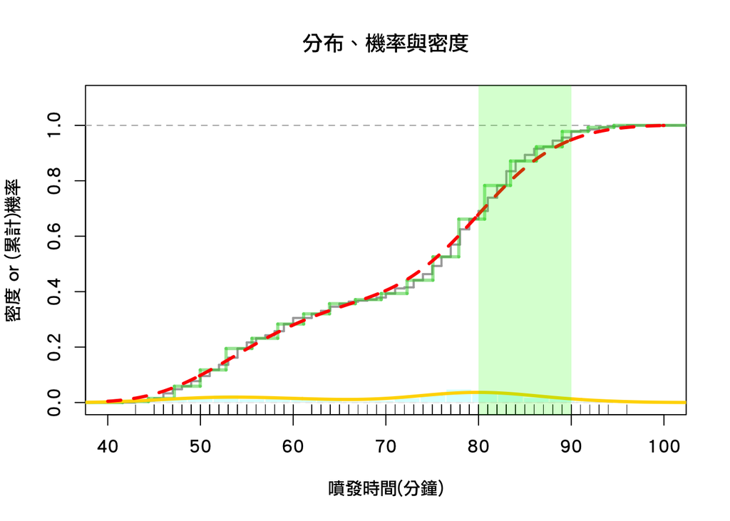

```r
# Frame
plot(0,0,xlim=c(40,100),ylim=c(0,1.1),xlab="噴發時間(分鐘)", #將xlim改為(40,100)
     ylab="密度 or (累計)機率", main="分布、機率與密度",family = 'LiHeiPro')
abline(h=1, col='lightgray', lwd=0.25, lty=2)

# Empirical PDF
rug(D)
# Empirical CDF
plot(ecdf(D), cex=0, verticals=T, lwd=2, col='darkgray', add=T)

# Histogram PDF
Bins = 20                             # no. bins
bx = seq(min(D), max(D), length=Bins) # break sequence
hist(D, col="#B3FFFF7F", border="white", ylim=c(0,1.1),
     freq=FALSE, breaks=bx, add=T)

abline(h=0, col='lightgray', lwd=0.25)
# Histogram CDF
adj = (bx[2] - bx[1])/2
steps = stepfun(bx-adj, c(0, sapply(bx, function(b) mean(D <= b))))
plot(steps, cex=0, col='#33CC337F', lwd=3, lty=1, add=T)

# Smooth PDF
Adjust = 1    # bandwidth adjustment
DEN = density(D, adjust = Adjust)
lines(DEN, col='gold', lwd=3)
# Smooth CDF
PDF = approxfun(DEN$x, DEN$y, yleft=0, yright=0)
x = seq(40,100,0.1)  #將時間範圍改成40~100,每0.1設為一個區間
y = sapply(x, function(i) integrate(PDF, -Inf, i)$value)
lines(x, y, col='red', lwd=3, lty=2)

# Mark Range
x1 = 80
x2 = 90
rect(x1,-0.1,x2,1.2,col= rgb(0,1,0,alpha=0.2),border=NA)
```

```r
# x = seq(x1, x2, length=100)
# polygon(c(x, x2, x1),  c(PDF(x), 0, 0), col="#FF99003F", border=NA)
# Calculate Probability
integrate(PDF, x1, x2)$value
```

```
## [1] 0.2685065
```